# Assignment_2

Chaitanya

2024-02-25

#Summary: This Assignment objective for knn classification by using the universal bank dataset contains 5000 customers data. Therefore, categorical variables will merge with dummy variables. whether the loan is accepted or rejected. There we can use train, test and validation set. Partition the data into training (60%) and validation (40%) sets.By using the confusion matrix using performance measurement.KNN will be k=1 for personal loan.

```r
## Packages used to create Knn for Classification
library('caret')
library('ISLR')
library('dplyr')
library('class')
library('gmodels')
library('FNN')
```

```r
library("ggplot2")
## Import the Dataset from the pc location.
Bank <- read.csv("C:\\Users\\Chaitu\\Documents\\UniversalBank.csv")
```

```r
Bank$ZIP.Code <- NULL
Bank$ID <- NULL
summary(Bank)
```

```
##       Age          Experience       Income           Family
##  Min.   :23.00   Min.   :-3.0   Min.   :  8.00   Min.   :1.000
##  1st Qu.:35.00   1st Qu.:10.0   1st Qu.: 39.00   1st Qu.:1.000
##  Median :45.00   Median :20.0   Median : 64.00   Median :2.000
##  Mean   :45.34   Mean   :20.1   Mean   : 73.77   Mean   :2.396
##  3rd Qu.:55.00   3rd Qu.:30.0   3rd Qu.: 98.00   3rd Qu.:3.000
##  Max.   :67.00   Max.   :43.0   Max.   :224.00   Max.   :4.000
##      CCAvg          Education        Mortgage     Personal.Loan
##  Min.   : 0.000   Min.   :1.000   Min.   :  0.0   Min.   :0.000
##  1st Qu.: 0.700   1st Qu.:1.000   1st Qu.:  0.0   1st Qu.:0.000
##  Median : 1.500   Median :2.000   Median :  0.0   Median :0.000
##  Mean   : 1.938   Mean   :1.881   Mean   : 56.5   Mean   :0.096
##  3rd Qu.: 2.500   3rd Qu.:3.000   3rd Qu.:101.0   3rd Qu.:0.000
##  Max.   :10.000   Max.   :3.000   Max.   :635.0   Max.   :1.000
##  Securities.Account   CD.Account         Online         CreditCard
##  Min.   :0.0000     Min.   :0.0000   Min.   :0.0000   Min.   :0.000
##  1st Qu.:0.0000     1st Qu.:0.0000   1st Qu.:0.0000   1st Qu.:0.000
##  Median :0.0000     Median :0.0000   Median :1.0000   Median :0.000
##  Mean   :0.1044     Mean   :0.0604   Mean   :0.5968   Mean   :0.294
##  3rd Qu.:0.0000     3rd Qu.:0.0000   3rd Qu.:1.0000   3rd Qu.:1.000
##  Max.   :1.0000     Max.   :1.0000   Max.   :1.0000   Max.   :1.000
```

##using Personal.loan as a function() factor.

```r
Bank$Personal.Loan = as.factor(Bank$Personal.Loan)
Normal_Data <- preProcess(Bank,method = "range")
Bank_Norm <- predict(Normal_Data,Bank)
summary(Bank_Norm)
```

```
##       Age           Experience         Income           Family
##  Min.   :0.0000   Min.   :0.0000   Min.   :0.0000   Min.   :0.0000
##  1st Qu.:0.2727   1st Qu.:0.2826   1st Qu.:0.1435   1st Qu.:0.0000
##  Median :0.5000   Median :0.5000   Median :0.2593   Median :0.3333
##  Mean   :0.5077   Mean   :0.5023   Mean   :0.3045   Mean   :0.4655
##  3rd Qu.:0.7273   3rd Qu.:0.7174   3rd Qu.:0.4167   3rd Qu.:0.6667
##  Max.   :1.0000   Max.   :1.0000   Max.   :1.0000   Max.   :1.0000
##      CCAvg          Education         Mortgage       Personal.Loan
##  Min.   :0.0000   Min.   :0.0000   Min.   :0.00000   0:4520
##  1st Qu.:0.0700   1st Qu.:0.0000   1st Qu.:0.00000   1: 480
##  Median :0.1500   Median :0.5000   Median :0.00000
##  Mean   :0.1938   Mean   :0.4405   Mean   :0.08897
##  3rd Qu.:0.2500   3rd Qu.:1.0000   3rd Qu.:0.15906
##  Max.   :1.0000   Max.   :1.0000   Max.   :1.00000
##  Securities.Account   CD.Account         Online         CreditCard
##  Min.   :0.0000     Min.   :0.0000   Min.   :0.0000   Min.   :0.000
##  1st Qu.:0.0000     1st Qu.:0.0000   1st Qu.:0.0000   1st Qu.:0.000
##  Median :0.0000     Median :0.0000   Median :1.0000   Median :0.000
##  Mean   :0.1044     Mean   :0.0604   Mean   :0.5968   Mean   :0.294
##  3rd Qu.:0.0000     3rd Qu.:0.0000   3rd Qu.:1.0000   3rd Qu.:1.000
##  Max.   :1.0000     Max.   :1.0000   Max.   :1.0000   Max.   :1.000
```

## DataPartitioning the universalbank into training (60%) and validation (40%).

```r
Train_index <- createDataPartition(Bank$Personal.Loan, p = 0.6,
list = FALSE)
train.df = Bank_Norm[Train_index,]
validation.df = Bank_Norm[-Train_index,]
```

##1)Customer Data as provided to predict given information

```r
Predict = data.frame(Age = 40, Experience = 10, Income = 84, Family = 2,
CCAvg = 2, Education = 1, Mortgage = 0, Securities.Account = 0, CD.Account = 0,
Online = 1, CreditCard = 1)
print(Predict)
```

```
##   Age Experience Income Family CCAvg Education Mortgage Securities.Account
## 1  40         10     84      2     2         1        0                  0
##   CD.Account Online CreditCard
## 1          0      1          1
```

```r
Prediction <- knn(train = train.df[,1:7],test = Predict[,1:7],
cl = train.df$Personal.Loan, k = 1)
print(Prediction)
```

```
## [1] 1
## attr(,"nn.index")
##      [,1]
## [1,]  550
## attr(,"nn.dist")
##         [,1]
## [1,] 92.3269
## Levels: 1
```

##2)K balances between overfitting and ignoring the predictor information

```r
set.seed(124)
Bank_run <- trainControl(method= "repeatedcv", number = 5, repeats = 2)
searchGrid = expand.grid(k=1:10)
knn.model = train(Personal.Loan~., data = train.df, method = 'knn', tuneGrid = searchGrid, trControl = Bank_run)
knn.model
```

```
## k-Nearest Neighbors
##
## 3000 samples
##   11 predictor
##    2 classes: '0', '1'
##
## No pre-processing
## Resampling: Cross-Validated (5 fold, repeated 2 times)
## Summary of sample sizes: 2400, 2399, 2400, 2400, 2401, 2400, ...
## Resampling results across tuning parameters:
##
##   k   Accuracy   Kappa
##    1  0.9539977  0.6986081
##    2  0.9484991  0.6571442
##    3  0.9528311  0.6654330
##    4  0.9493319  0.6330751
##    5  0.9493316  0.6300402
##    6  0.9438333  0.5839986
##    7  0.9446661  0.5838031
##    8  0.9428319  0.5637401
##    9  0.9428336  0.5629804
##   10  0.9406672  0.5393058
##
## Accuracy was used to select the optimal model using the largest value.
## The final value used for the model was k = 1.
```

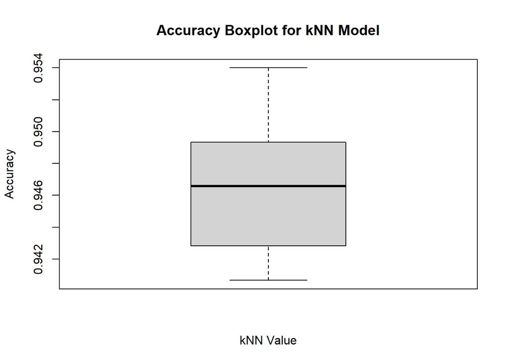

```r
# Extracting the accuracy values from the knn.model
accuracy_values <- knn.model$results$Accuracy

# A boxplot for the accuracy values
boxplot(accuracy_values,
        main = "Accuracy Boxplot for kNN Model",
        xlab = "kNN Value",
        ylab = "Accuracy")
```

```r
top_k <- knn.model$bestTune[[1]]
top_k
```

```
## [1] 1
```

##3 Show the confusion matrix for the validation data that results from using the best k.

```r
predictions <- predict(knn.model,validation.df)
confusionMatrix(predictions,validation.df$Personal.Loan)
```

```
## Confusion Matrix and Statistics
##
##           Reference
## Prediction    0    1
##          0 1791   57
##          1   17  135
##
##                Accuracy : 0.963
##                  95% CI : (0.9538, 0.9708)
##     No Information Rate : 0.904
##     P-Value [Acc > NIR] : < 2.2e-16
##
##                   Kappa : 0.7649
##
##  Mcnemar's Test P-Value : 5.797e-06
##
##             Sensitivity : 0.9906
##             Specificity : 0.7031
##          Pos Pred Value : 0.9692
##          Neg Pred Value : 0.8882
##              Prevalence : 0.9040
##          Detection Rate : 0.8955
##    Detection Prevalence : 0.9240
##       Balanced Accuracy : 0.8469
##
##        'Positive' Class : 0
##
```

##4 As given data below for Classification the customer using the best k

```r
PredictNorm = data.frame(Age = 40, Experience = 10, Income = 84,
Family = 2,CCAvg = 2, Education = 1, Mortgage = 0,Securities.Account =0,
CD.Account = 0, Online = 1,CreditCard = 1)
Predict_Norm = predict(Normal_Data, Predict)
predict(knn.model, PredictNorm)
```

```
## [1] 1
## Levels: 0 1
```

##5) Repartition the data, this time into training, validation, and test sets (50% : 30% : 20%). By Applying the k-NN method.

```r
Train_index = createDataPartition(Bank$Personal.Loan, p = 0.5,
list = FALSE)
train.df = Bank_Norm[Train_index,]
Test_index = createDataPartition(Bank$Personal.Loan, p = 0.2,
list = FALSE)
Test.df = Bank_Norm[Test_index,]
```

```r
Validation_index= createDataPartition(Bank$Personal.Loan, p = 0.3,
list = FALSE)
validation.df = Bank_Norm[Validation_index,]
knnTesting <- knn(train = train.df[,-8], test = Test.df[,-8], cl = train.df[,8],
k =3)
knnValidation <- knn(train = train.df[,-8],
test = validation.df[,-8], cl = train.df[,8], k =3)
knnTraining <- knn(train = train.df[,-8],
test = train.df[,-8], cl = train.df[,8], k =3)
```

##confusion matrix for training, Testing & validation sets.

```r
confusionMatrix(knnTesting, Test.df[,8])
```

```
## Confusion Matrix and Statistics
##
##           Reference
## Prediction   0   1
##          0 901  30
##          1   3  66
##
##                Accuracy : 0.967
##                  95% CI : (0.954, 0.9772)
##     No Information Rate : 0.904
##     P-Value [Acc > NIR] : 1.058e-14
##
##                   Kappa : 0.7825
##
##  Mcnemar's Test P-Value : 6.011e-06
##
##             Sensitivity : 0.9967
##             Specificity : 0.6875
##          Pos Pred Value : 0.9678
##          Neg Pred Value : 0.9565
##              Prevalence : 0.9040
##          Detection Rate : 0.9010
##    Detection Prevalence : 0.9310
##       Balanced Accuracy : 0.8421
##
##        'Positive' Class : 0
##
```

```r
confusionMatrix(knnTraining, train.df[,8])
```

```
## Confusion Matrix and Statistics
##
##           Reference
## Prediction    0    1
##          0 2255   54
##          1    5  186
##
##                Accuracy : 0.9764
##                  95% CI : (0.9697, 0.982)
##     No Information Rate : 0.904
##     P-Value [Acc > NIR] : < 2.2e-16
##
##                   Kappa : 0.8504
##
##  Mcnemar's Test P-Value : 4.129e-10
##
##             Sensitivity : 0.9978
##             Specificity : 0.7750
##          Pos Pred Value : 0.9766
##          Neg Pred Value : 0.9738
##              Prevalence : 0.9040
##          Detection Rate : 0.9020
##    Detection Prevalence : 0.9236
##       Balanced Accuracy : 0.8864
##
##        'Positive' Class : 0
##
```

```r
confusionMatrix(knnValidation, validation.df[,8])
```

```
## Confusion Matrix and Statistics
##
##           Reference
## Prediction    0    1
##          0 1350   54
##          1    6   90
##
##                Accuracy : 0.96
##                  95% CI : (0.9488, 0.9693)
##     No Information Rate : 0.904
##     P-Value [Acc > NIR] : < 2.2e-16
##
##                   Kappa : 0.7292
##
##  Mcnemar's Test P-Value : 1.298e-09
##
##             Sensitivity : 0.9956
##             Specificity : 0.6250
##          Pos Pred Value : 0.9615
##          Neg Pred Value : 0.9375
##              Prevalence : 0.9040
##          Detection Rate : 0.9000
##    Detection Prevalence : 0.9360
##       Balanced Accuracy : 0.8103
##
##        'Positive' Class : 0
##
```